# Cодержание

- 1-Обзор данных
- 2-Предобработка данных
  - 2.1-Обработка явных дубликатов
- 3-Исследовательский анализ данных
  - 3.1-Статистический анализ
    - 3.1.1-Анализ таблицы geo_data_0
    - 3.1.2-Анализ таблицы geo_data_1
    - 3.1.3-Анализ таблицы geo_data_2
  - 3.2-Статистический анализ: выводы
  - 3.3-Корреляционный анализ
- 4-Обучение модели
  - 4.1-Создание пайплайна
  - 4.2-Обучение модели
    - 4.2.1-Обучение и предсказание на данных good_geo_data_0
    - 4.2.2-Обучение и предсказание на данных good_geo_data_1
    - 4.2.3-Обучение и предсказание на данных good_geo_data_2
- 5-Расчёт прибыли
  - 5.1-Подготовка к расчёту прибыли
  - 5.2-Расчёт прибыли
  - 5.3-Подсчёт рисков и прибыли для регионов
- 6-Общий вывод

# Выбор локации для скважины

**Цель исследования**: выбрать локацию для бурения новой скважины для добывающей компании «ГлавРосГосНефть».

Для достижения цели выполним следующие **задачи**:

- Построим модель для определения региона, где добыча принесёт наибольшую прибыль;
- Проанализируем возможную прибыль и риски техникой Bootstrap.

**Описание данных**:

В ходе исследования будут использованы данные геологоразведки трёх регионов. Мы получим их из трёх файлов: `geo_data_0.csv`, `geo_data_1.csv`, `geo_data_2.csv`.

Таблицы содержат следующие признаки:

- `id` — уникальный идентификатор скважины;
- `f0`, `f1`, `f2` — три признака точек;
- `product` — объём запасов в скважинах (тысячи баррелей).

**Этапы исследования**:

1. Обзор данных

Ознакомимся со структурой и особенностями данных, предварительно выявим возможные проблемы.

2. Предобработка данных

Проведём более тщательный поиск ошибок и мусора в данных. Подготовим датафреймы к обучению модели.

3. Исследовательский анализ данных

Проведём статистический и корреляционный анализ. При необходимости устраним аномалии и выбросы, а также отберём признаки с высокой корреляцией для моделирования.

4. Обучение модели

Создадим пайплайн и обучим модель `LinearRegression`. Спрогнозируем целевой признак `product` для трёх регионов и проверим качество модели.

5. Подсчёт прибыли

Используем технику `Bootstrap` для анализа возможной прибыли и рисков.

## Обзор данных

Импортируем необходимые библиотеки:

```python
# библиотеки для исследовательского анализа и визуализации
import pandas as pd
import matplotlib.pyplot as plt
import seaborn as sns
import phik
import numpy as np

# библиотеки для обучения модели
# константы (разбиваем данные на обучающую и валидационные выборки в соотношении 75:25)
RANDOM_STATE = 42
TEST_SIZE = 0.25

# классы для работы с пайплайном
from sklearn.pipeline import Pipeline
from sklearn.compose import ColumnTransformer
from sklearn.impute import SimpleImputer

# классы для масштабирования данных
from sklearn.preprocessing import(
    RobustScaler,
    StandardScaler,
    MinMaxScaler,
    FunctionTransformer
)

# классы для деления данных на выборки и перебора гиперпараметров
from sklearn.model_selection import(
    train_test_split,
    GridSearchCV
)

# модель
from sklearn.linear_model import LinearRegression

# класс для оценки модели
from sklearn.metrics import mean_squared_error as mse
```

Сохраним три CSV-таблицы в датафреймы:

```python
# считаем информацию с помощью pandas и сохраним её в датафреймы
geo_data_0 = pd.read_csv('https://code.s3.yandex.net/datasets/geo_data_0.csv')
geo_data_1 = pd.read_csv('https://code.s3.yandex.net/datasets/geo_data_1.csv')
geo_data_2 = pd.read_csv('https://code.s3.yandex.net/datasets/geo_data_2.csv')
```

Ознакомимся с основной информацией в таблицах. Выведем первые 20 строк каждого датафрейма:

```python
# выведем первые 20 строк таблицы geo_data_0
geo_data_0.head(20)
```

|  | id | f0 | f1 | f2 | product |
| --- | --- | --- | --- | --- | --- |
| 0 | txEyH | 0.705745 | -0.497823 | 1.221170 | 105.280062 |
| 1 | 2acmU | 1.334711 | -0.340164 | 4.365080 | 73.037750 |
| 2 | 409Wp | 1.022732 | 0.151990 | 1.419926 | 85.265647 |
| 3 | iJLyR | -0.032172 | 0.139033 | 2.978566 | 168.620776 |
| 4 | Xdl7t | 1.988431 | 0.155413 | 4.751769 | 154.036647 |
| 5 | wX4Hy | 0.969570 | 0.489775 | -0.735383 | 64.741541 |
| 6 | tL6pL | 0.645075 | 0.530656 | 1.780266 | 49.055285 |
| 7 | BYPU6 | -0.400648 | 0.808337 | -5.624670 | 72.943292 |
| 8 | j9Oui | 0.643105 | -0.551583 | 2.372141 | 113.356160 |
| 9 | OLuZU | 2.173381 | 0.563698 | 9.441852 | 127.910945 |
| 10 | b8WQ6 | 0.371066 | -0.036585 | 0.009208 | 70.326617 |
| 11 | 1YYm1 | 0.015920 | 1.062729 | -0.722248 | 45.110381 |
| 12 | zIYPq | -0.276476 | 0.924865 | 0.095584 | 89.158678 |
| 13 | iqTqq | 0.212696 | -0.111147 | 5.770095 | 164.298520 |
| 14 | Ct5yY | -0.018578 | 0.187516 | 2.944683 | 158.633720 |
| 15 | Q77WQ | 1.324566 | -0.419149 | -4.097429 | 60.677876 |
| 16 | 6vJcD | -0.000247 | 0.360146 | 0.794115 | 163.143987 |
| 17 | AgRR6 | 0.380913 | 1.114558 | 0.992377 | 125.942543 |
| 18 | tgSSC | 0.160021 | 0.788151 | 7.629164 | 113.793566 |
| 19 | s2g8E | 0.593078 | -0.414964 | -0.715774 | 28.207978 |

```python
# выведем первые 20 строк таблицы geo_data_1
geo_data_1.head(20)
```

|  | id | f0 | f1 | f2 | product |
| --- | --- | --- | --- | --- | --- |
| 0 | kBEdx | -15.001348 | -8.276000 | -0.005876 | 3.179103 |
| 1 | 62mP7 | 14.272088 | -3.475083 | 0.999183 | 26.953261 |
| 2 | vyE1P | 6.263187 | -5.948386 | 5.001160 | 134.766305 |
| 3 | KcrkZ | -13.081196 | -11.506057 | 4.999415 | 137.945408 |
| 4 | AHL4O | 12.702195 | -8.147433 | 5.004363 | 134.766305 |
| 5 | HHckp | -3.327590 | -2.205276 | 3.003647 | 84.038886 |
| 6 | h5Ujo | -11.142655 | -10.133399 | 4.002382 | 110.992147 |
| 7 | muH9x | 4.234715 | -0.001354 | 2.004588 | 53.906522 |
| 8 | YiRkx | 13.355129 | -0.332068 | 4.998647 | 134.766305 |
| 9 | jG6Gi | 1.069227 | -11.025667 | 4.997844 | 137.945408 |
| 10 | 7uHUe | 11.777049 | -5.334084 | 2.003033 | 53.906522 |
| 11 | OXyvW | 16.320755 | -0.562946 | -0.001783 | 0.000000 |
| 12 | cB8re | 7.736313 | -6.093374 | 3.982531 | 107.813044 |
| 13 | igmai | 6.695604 | -0.749449 | -0.007630 | 0.000000 |
| 14 | 3OdkE | -10.985487 | -5.605994 | 2.991130 | 84.038886 |
| 15 | 3tVUO | -0.347599 | -6.275884 | -0.003448 | 3.179103 |
| 16 | siveY | 12.300570 | 2.944454 | 2.005541 | 53.906522 |
| 17 | gIqzq | 8.900460 | -5.632857 | 4.994324 | 134.766305 |
| 18 | zO5EU | -13.412826 | -4.729495 | 2.998590 | 84.038886 |
| 19 | dkcEb | -4.373526 | -8.590017 | 2.995379 | 84.038886 |

```python
# выведем первые 20 строк таблицы geo_data_2
geo_data_2.head(20)
```

|  | id | f0 | f1 | f2 | product |
| --- | --- | --- | --- | --- | --- |
| 0 | fwXo0 | -1.146987 | 0.963328 | -0.828965 | 27.758673 |
| 1 | WJtFt | 0.262778 | 0.269839 | -2.530187 | 56.069697 |
| 2 | ovLUW | 0.194587 | 0.289035 | -5.586433 | 62.871910 |
| 3 | q6cA6 | 2.236060 | -0.553760 | 0.930038 | 114.572842 |
| 4 | WPMUX | -0.515993 | 1.716266 | 5.899011 | 149.600746 |
| 5 | LzZXx | -0.758092 | 0.710691 | 2.585887 | 90.222465 |
| 6 | WBHRv | -0.574891 | 0.317727 | 1.773745 | 45.641478 |
| 7 | XO8fn | -1.906649 | -2.458350 | -0.177097 | 72.480640 |
| 8 | ybmQ5 | 1.776292 | -0.279356 | 3.004156 | 106.616832 |
| 9 | OilcN | -1.214452 | -0.439314 | 5.922514 | 52.954532 |
| 10 | myq2g | 0.628659 | -2.120049 | 5.362437 | 166.799132 |
| 11 | V9R1y | -0.544565 | 0.039088 | 8.635293 | 150.859435 |
| 12 | bKDo0 | -0.960453 | -0.127113 | 7.764734 | 96.910855 |
| 13 | eXvhs | 1.432891 | -1.242074 | 3.557168 | 8.704162 |
| 14 | wI4j3 | -0.935464 | 2.420523 | 1.150536 | 116.829811 |
| 15 | XOWTx | -2.628353 | 0.937303 | 0.057847 | 68.655498 |
| 16 | 2oVFv | -0.428050 | -2.246556 | 6.970420 | 84.500464 |
| 17 | 0wbDA | 0.735307 | 0.913124 | 7.899539 | 96.284701 |
| 18 | NhHaR | 0.706261 | -0.993553 | 3.155582 | 48.052268 |
| 19 | DMNMZ | -1.867846 | 2.744144 | 5.918278 | 153.815137 |

- Во всех 3 таблицах корректно обозначены названия столбцов, однако столбец `id` содержит в строках элементы в разном регистре (например, "2oVFv" или "WPMUX", "myq2g"). Пока непонятно, пригодится ли этот столбец в исследовании.
- Столбцы f0, f1 и f2 включают отрицательные и положительные значения. Информация о значении признаков отсутствует, но мы знаем, что признаки значимы.
- Данные в столбце `product` означают баррели в тысячах. Значения кажутся реалистичными.

Изучим основные характеристики данных в датафреймах:

```python
# выведем основную информацию с помощью info()
geo_data_0.info()
```

```
<class 'pandas.core.frame.DataFrame'>
RangeIndex: 100000 entries, 0 to 99999
Data columns (total 5 columns):
 #   Column   Non-Null Count   Dtype
---  ------   --------------   -----
 0   id       100000 non-null  object
 1   f0       100000 non-null  float64
 2   f1       100000 non-null  float64
 3   f2       100000 non-null  float64
 4   product  100000 non-null  float64
dtypes: float64(4), object(1)
memory usage: 3.8+ MB
```

```python
# выведем основную информацию
geo_data_1.info()
```

```
<class 'pandas.core.frame.DataFrame'>
RangeIndex: 100000 entries, 0 to 99999
Data columns (total 5 columns):
 #   Column   Non-Null Count   Dtype
---  ------   --------------   -----
 0   id       100000 non-null  object
 1   f0       100000 non-null  float64
 2   f1       100000 non-null  float64
 3   f2       100000 non-null  float64
 4   product  100000 non-null  float64
dtypes: float64(4), object(1)
memory usage: 3.8+ MB
```

```python
# выведем основную информацию
geo_data_2.info()
```

```
<class 'pandas.core.frame.DataFrame'>
RangeIndex: 100000 entries, 0 to 99999
Data columns (total 5 columns):
 #   Column   Non-Null Count   Dtype
---  ------   --------------   -----
 0   id       100000 non-null  object
 1   f0       100000 non-null  float64
 2   f1       100000 non-null  float64
 3   f2       100000 non-null  float64
 4   product  100000 non-null  float64
dtypes: float64(4), object(1)
memory usage: 3.8+ MB
```

- В каждой таблице по **5** столбцов и **100 000** наблюдений;
- Во всех таблицах корректно обозначен тип данных, отсутствуют пропуски.

## Предобработка данных

### Обработка явных дубликатов

Приведём `id` в таблицах к нижнему регистру, затем проведём проверку на явные дубли в столбце:

```python
# сохраним список с таблицами для цикла
geo_data = [geo_data_0, geo_data_1, geo_data_2]

# в цикле переберём все элементы списка geo_data
# поочередно приведем столбцы id во всех таблицах к нижнему регистру, сохраним результат
# затем каждый датафрейм проверим на явные дубли, выведем результат
for i in range(3):
    geo_data[i]['id'] = geo_data[i]['id'].str.lower()
    print(f'в таблице geo_data_{i} найдено {geo_data[i].duplicated().sum()} явных дубликатов')
```

```
в таблице geo_data_0 найдено 0 явных дубликатов
в таблице geo_data_1 найдено 0 явных дубликатов
в таблице geo_data_2 найдено 0 явных дубликатов
```

Во всех таблицах отсутствуют явные дубли.

## Исследовательский анализ данных

### Статистический анализ

- Построим гистограммы и посмотрим, как распределены значения в количественных столбцах трёх датафреймов;
- С помощью диаграммы размаха определим, есть ли в данных выбросы или аномалии. При необходимости отфильтруем данные.

#### Анализ таблицы geo_data_0

Построим гистограмму и диаграмму размаха по столбцу `f0`:

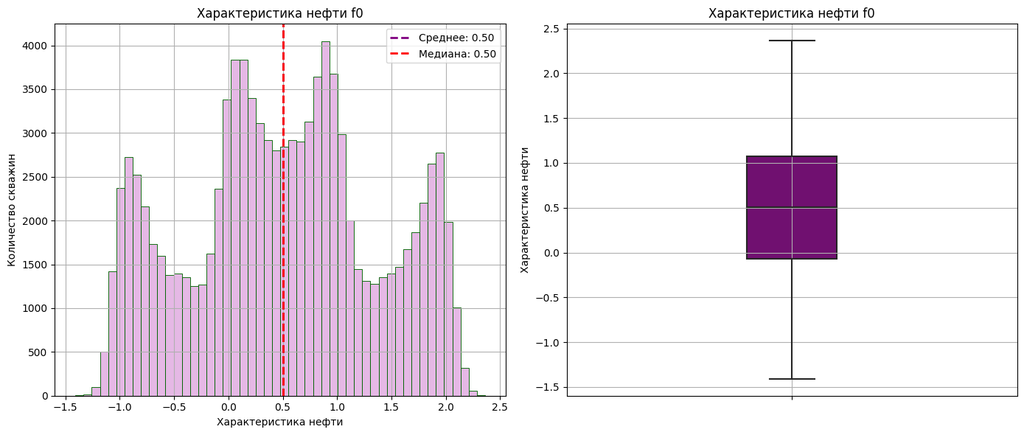

```python
# напишем функцию для построения гистограммы и boxplot
def hist_boxplot_creation(data, column, title, bins, xlabel, ylabel, color_1, color_2):
    # создадим сетку графиков
    fig, axes = plt.subplots(1, 2, figsize=(14,6))
    # сохраним в переменную датафрейм с нужным столбцом
    # рассчитаем медиану и среднее
    data = data[column]
    data_mean = data.mean()
    data_median = data.median()

    # построим гистограмму
    sns.histplot(data=data, bins=bins, ax=axes[0], color=color_1, edgecolor='darkgreen')
    axes[0].set_title(title)
    axes[0].set_xlabel(xlabel)
    axes[0].set_ylabel(ylabel)
    axes[0].grid(True)

    # добавим медиану и среднее на гистограмму
    axes[0].axvline(
        data_mean,
        color='purple',
        linestyle='dashed',
        linewidth=2,
        label=f'Среднее: {data_mean:.2f}'
    )
    axes[0].axvline(
        data_median,
        color='red',
        linestyle='dashed',
        linewidth=2,
        label=f'Медиана: {data_median:.2f}'
    )

    # отобразим среднее и медиану на графике
    axes[0].legend()

    # построим диаграмму размаха
    sns.boxplot(y=data, color=color_2, ax=axes[1], width=0.2)
    axes[1].set_title(title)
    axes[1].set_ylabel(xlabel)
    axes[1].grid(True)

    # отобразим графики
    plt.tight_layout()
    return plt.show()

# вызовем функцию
hist_boxplot_creation(geo_data_0, 'f0', 'Характеристика нефти f0', 50, 'Характеристика нефти', 'Количество скважин', 'plum', 'purple')
```

- График показывает мультимодальное распределение с **4** выраженными пиками. Можно предположить, что в данных есть несколько групп скважин со схожими характеристиками;
- Распределение симметрично. Среднее и медиана совпадают — **0.50**;
- Соглано диаграмме размаха, в данных отсутствуют выбросы.

Проанализируем распределение значений в столбце `f1`:

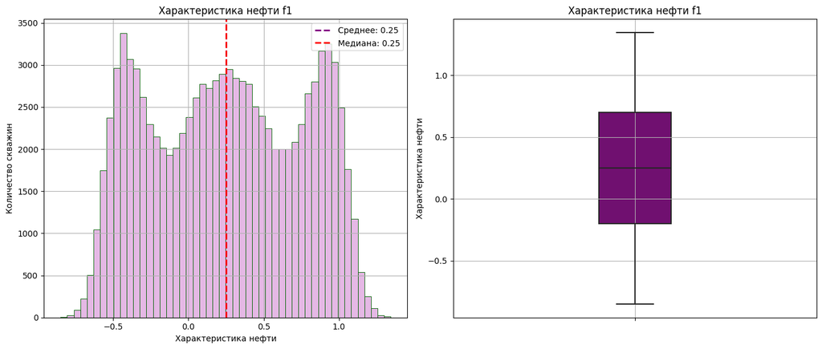

```python
# вызовем функцию для построения диаграмм
hist_boxplot_creation(geo_data_0, 'f1', 'Характеристика нефти f1', 50, 'Характеристика нефти', 'Количество скважин', 'plum', 'purple')
```

- Значения также распределены симметрично. Распределение — мультимодальное с **3** пиками;
- Диаграмма размаха показывает отсутствие выбросов.

Посмотрим, как распределены значения в столбце `f2` и есть ли в нём выбросы:

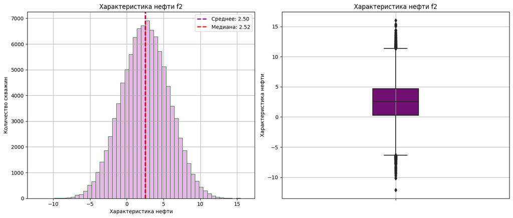

```python
# вызовем функцию для построения диаграмм
hist_boxplot_creation(geo_data_0, 'f2', 'Характеристика нефти f2', 50, 'Характеристика нефти', 'Количество скважин', 'plum', 'purple')
```

- На диаграмме можно увидель нормальное распределение с длинными тонкими хвостами из выбросов слева и справа;
- Медианное значение — **2.52** незначительно выше среднего арифметического — **2.50**.

Рассчитаем границы нормального размаха и отфильтруем выбросы в столбце:

```python
# напишем функцию для расчёта межквартильного размаха
def emissions_limit(data, column):
    Q1 = data[column].quantile(0.25)
    Q3 = data[column].quantile(0.75)
    IQR = Q3-Q1
    upper_limit = Q3 + 1.5 * IQR
    lower_limit = Q1 - 1.5 * IQR
# напечатаем результат
    return f'Верхняя граница = {upper_limit}, нижняя граница = {lower_limit}'

# вызовем функцию
emissions_limit(geo_data_0, 'f2')
```

```
'Верхняя граница = 11.356097512311544, нижняя граница = -6.3532614580838125'
```

```python
# сохраним копию исходного датафрейма
good_geo_data_0 = geo_data_0.copy()

# напишем функцию для фильтрации значений в столбце согласно верхней и нижней границам
def filtered_data(data, column, upper_limit, lower_limit):
    data = data.query(f'{column} <= {upper_limit} and {column} >= {lower_limit}')
    sorted_ascending_false = data[column].sort_values(ascending=False).head(10)
    sorted_ascending_true = data[column].sort_values().head(10)
    print (f'проверка верхней границы:\n{sorted_ascending_false},\nпроверка нижней границы:\n{sorted_ascending_true}')
    return data

# сохраним и проверим результат
good_geo_data_0 = filtered_data(good_geo_data_0, 'f2', 11.356, -6.353)
```

```
проверка верхней границы:
76485    11.353804
68472    11.348775
92935    11.341927
86439    11.341107
27072    11.340392
18148    11.331497
38085    11.327330
26163    11.326781
36245    11.324506
37092    11.324006
Name: f2, dtype: float64,
проверка нижней границы:
52580   -6.352956
82424   -6.350371
81405   -6.349353
37828   -6.343098
65560   -6.342176
63110   -6.341713
52220   -6.336175
37790   -6.333301
3424    -6.331667
26320   -6.330670
Name: f2, dtype: float64
```

Построим `boxplot` и `histplot` по столбцу `product`:

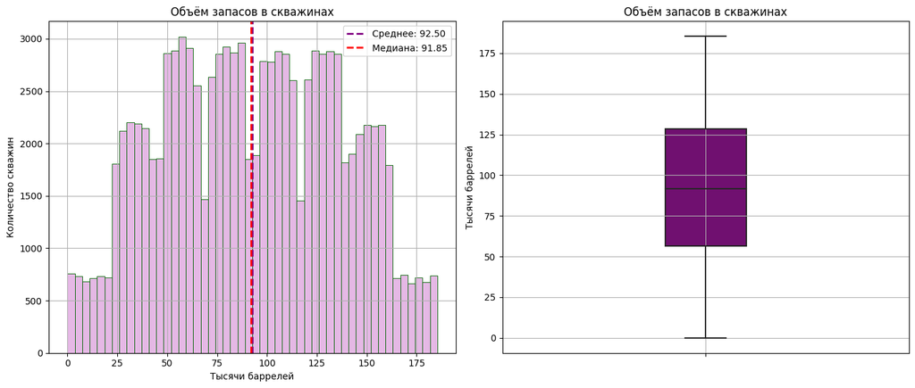

```python
# вызовем функцию для построения диаграмм
hist_boxplot_creation(geo_data_0, 'product', 'Объём запасов в скважинах', 50, 'Тысячи баррелей', 'Количество скважин', 'plum', 'purple')
```

- Распределение близко к симметричному, медианное значение незначительно меньше среднего — **91.85** и **92.50**;
- "Ящик с усами" показывает отсутствие выбросов в столбце.

#### Анализ таблицы geo_data_1

Аналогично проанализируем распределение в столбцах `f0`, `f1` и `f2`:

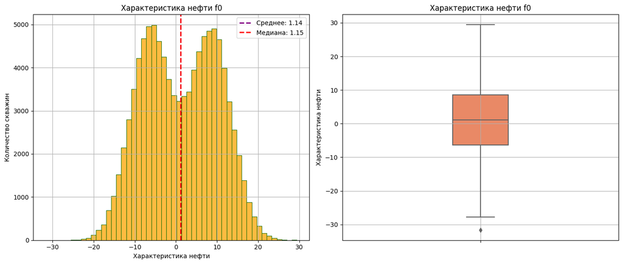

```python
# вызовем функцию для построения histplot и boxplot
hist_boxplot_creation(geo_data_1, 'f0', 'Характеристика нефти f0', 50, 'Характеристика нефти', 'Количество скважин', 'orange', 'coral')
```

- На гистограмме можно заметить бимодальное распределение с **2** пиками: приблизительно у отметок в **-8** и **10**;
- Диаграмма размаха показывает выброс у нижней границы, ориентировочно у отметки **-32**.

Рассчитаем межквартильный размах и отфильтруем выбросы:

```python
# вызовем функцию для расчёта границ нормального размаха
emissions_limit(geo_data_1, 'f0')
```

```
'Верхняя граница = 31.000365467492706, нижняя граница = -28.677901128779617'
```

```python
# сохраним копию исходного датафрейма
good_geo_data_1 = geo_data_1.copy()

# вызовем функцию для фильтрации и сохраним результат
good_geo_data_1 = filtered_data(good_geo_data_1, 'f0', 31.0, -28.677)
```

```
проверка верхней границы:
87294    29.421755
48944    29.259062
58726    28.930829
52190    28.400992
19923    26.535304
18862    26.531697
25808    26.221647
60941    26.198000
5205     26.186100
7772     26.085892
Name: f0, dtype: float64,
проверка нижней границы:
25851   -27.829616
26531   -26.646255
91725   -24.950386
46437   -24.791720
91470   -24.775824
71285   -24.738401
95754   -24.602559
80439   -23.884180
68717   -23.865679
71859   -23.850365
Name: f0, dtype: float64
```

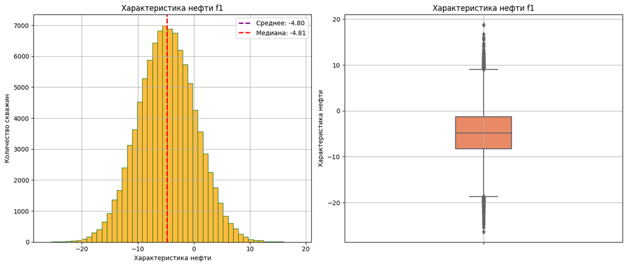

```python
# вызовем функцию для построения диаграмм
hist_boxplot_creation(geo_data_1, 'f1', 'Характеристика нефти f1', 50, 'Характеристика нефти', 'Количество скважин', 'orange', 'coral')
```

- Гистограмма показывает нормальное распределение с тонкими хвостами из выбросов, которые тянутся влево и вправо.

Удалим выбросы в столбце:

```python
# рассчитаем верхнюю и нижнюю границы
emissions_limit(geo_data_1, 'f1')
```

```
'Верхняя граница = 9.069937223519565, нижняя граница = -18.670738069582377'
```

```python
# отфильтруем выбросы по границам нормального размаха
good_geo_data_1 = filtered_data(good_geo_data_1, 'f1', 9.069, -18.670)
```

```
проверка верхней границы:
68487    9.050688
86580    9.045968
16521    9.029041
37220    9.018689
61874    9.017296
69742    9.014307
75693    9.012884
74138    9.006621
72747    9.003989
37542    8.993895
Name: f1, dtype: float64,
проверка нижней границы:
10771   -18.667777
33210   -18.649976
14554   -18.640133
86440   -18.634943
10804   -18.632918
93440   -18.628684
38320   -18.626037
16247   -18.625378
44059   -18.621194
15046   -18.620909
Name: f1, dtype: float64
```

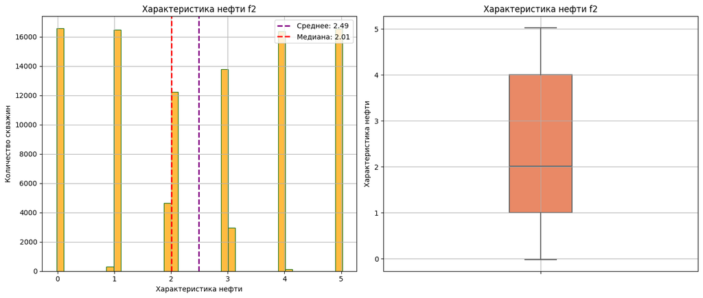

```python
# вызовем функцию для построения диаграмм
hist_boxplot_creation(geo_data_1, 'f2', 'Характеристика нефти f2', 40, 'Характеристика нефти', 'Количество скважин', 'orange', 'coral')
```

- На графике видно мультимодальное распределение с **6** модами. В данных много значений, сконцентрированных у отметок **0**, **1**, **2**, **3**, **4** и **5**;
- В столбце отсутствуют выбросы.

Проверим на наличие выбросов столбец с целевой переменной `product`:

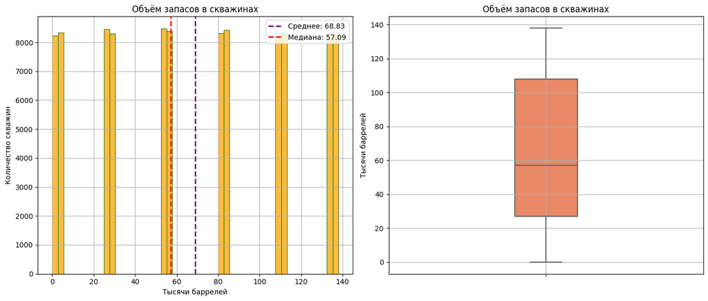

```python
# вызовем функцию для построения диаграмм
hist_boxplot_creation(geo_data_1, 'product', 'Объём запасов в скважинах', 50, 'Тысячи баррелей', 'Количество скважин', 'orange', 'coral')
```

- Гистограмма показывает мультимодальное распределение значений;
- Выбросы отсутствуют.

#### Анализ таблицы geo_data_2

Проверим на выбросы столбцы `f0`, `f1` и `f2`:

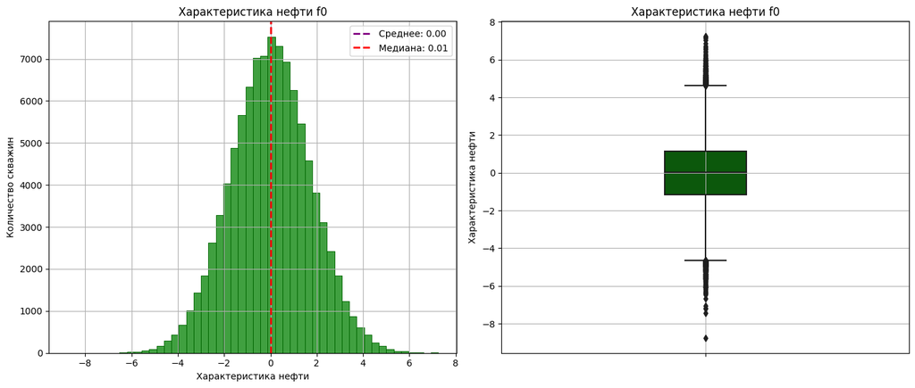

```python
# вызовем функцию
hist_boxplot_creation(geo_data_2, 'f0', 'Характеристика нефти f0', 50, 'Характеристика нефти', 'Количество скважин', 'green', 'darkgreen')
```

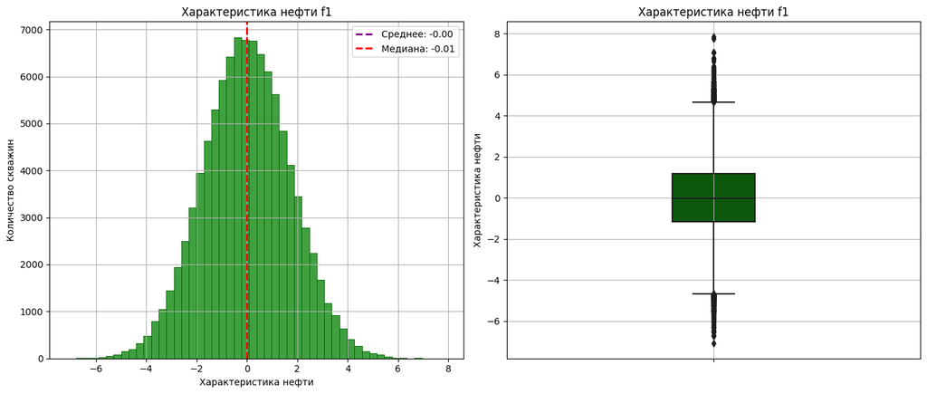

```python
# вызовем функцию
hist_boxplot_creation(geo_data_2, 'f1', 'Характеристика нефти f1', 50, 'Характеристика нефти', 'Количество скважин', 'green', 'darkgreen')
```

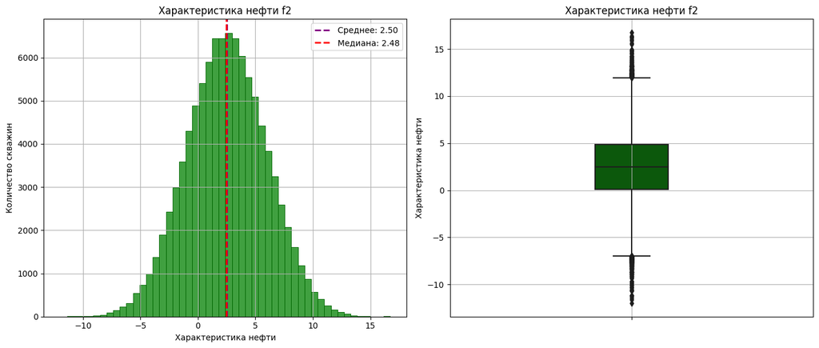

```python
# вызовем функцию
hist_boxplot_creation(geo_data_2, 'f2', 'Характеристика нефти f2', 50, 'Характеристика нефти', 'Количество скважин', 'green', 'darkgreen')
```

- Гистограммы по трём столбцам показывают нормальное распределение с выбросами по бокам.

Рассчитаем границы нормального размаха для трёх столбцов:

```python
# рассчитаем границы нормального размаха
emissions_limit(geo_data_2, 'f0')
```

```
'Верхняя граница = 4.639771092118378, нижняя граница = -4.643524223522959'
```

```python
# рассчитаем границы нормального размаха
emissions_limit(geo_data_2, 'f1')
```

```
'Верхняя граница = 4.671424081839961, нижняя граница = -4.682565825428671'
```

```python
# рассчитаем границы нормального размаха
emissions_limit(geo_data_2, 'f2')
```

```
'Верхняя граница = 11.951446027690594, нижняя граница = -6.962293786328402'
```

Удалим выбросы из столбцов:

```python
# создадим копию исходного датафрейма
good_geo_data_2 = geo_data_2.copy()

# удалим выбросы из f0
good_geo_data_2 = filtered_data(good_geo_data_2, 'f0', 4.639, -4.643)
```

```
проверка верхней границы:
79880    4.637965
63301    4.637266
41711    4.636639
73713    4.634796
45415    4.634103
57880    4.629695
30108    4.629693
75075    4.627969
52832    4.623072
21689    4.621378
Name: f0, dtype: float64,
проверка нижней границы:
12248   -4.640830
32129   -4.637494
71900   -4.636127
67089   -4.635688
80397   -4.635335
10357   -4.633796
87594   -4.633769
29845   -4.629041
22272   -4.628408
52439   -4.625954
Name: f0, dtype: float64
```

```python
# удалим выбросы из f1
good_geo_data_2 = filtered_data(good_geo_data_2, 'f1', 4.671, -4.682)
```

```
проверка верхней границы:
32109    4.670610
89626    4.668181
6941     4.667190
43797    4.660296
21178    4.654530
29132    4.653471
26194    4.652605
59326    4.650013
65005    4.649888
22491    4.649105
Name: f1, dtype: float64,
проверка нижней границы:
25855   -4.676782
45717   -4.676077
18868   -4.673547
73809   -4.668138
59731   -4.666255
27912   -4.665733
2594    -4.663550
16746   -4.663533
70488   -4.663342
1794    -4.662372
Name: f1, dtype: float64
```

```python
# удалим выбросы из f2
good_geo_data_2 = filtered_data(good_geo_data_2, 'f2', 11.951, -6.962)
```

```
проверка верхней границы:
50131    11.945919
45326    11.940473
20408    11.940008
67037    11.939636
19427    11.935824
80388    11.927669
88451    11.927515
45817    11.926242
7002     11.925167
59862    11.924714
Name: f2, dtype: float64,
проверка нижней границы:
57929   -6.944602
7958    -6.931512
39792   -6.920066
80462   -6.919914
95265   -6.914127
95884   -6.914019
32085   -6.910060
29165   -6.903111
98002   -6.902401
46616   -6.899536
Name: f2, dtype: float64
```

Построим графики по столбцу `product`:

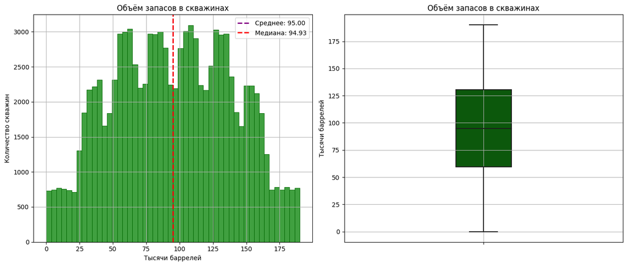

```python
# вызовем функцию
hist_boxplot_creation(geo_data_2, 'product', 'Объём запасов в скважинах', 50, 'Тысячи баррелей', 'Количество скважин', 'green', 'darkgreen')
```

- Распределение по целевому признаку близко к симметричному. В столбце отсутствуют выбросы.

### Статистический анализ: выводы

**Выводы**:

- Создали копии исходных датафреймов: `good_geo_data_0`, `good_geo_data_1`, `good_geo_data_2`;

Обнаружили и удалили выбросы во всех таблицах:

- В `good_geo_data_0` в столбце `f2`;
- В `good_geo_data_1` в столбце `f0`, `f1`;
- В `good_geo_data_2` в столбце `f0`, `f1`, `f2`.

### Корреляционный анализ

Рассчитаем коэффициенты корреляции всех признаков датафрейма `good_geo_data_0`:

```
interval columns not set, guessing: ['f0', 'f1', 'f2', 'product']
```

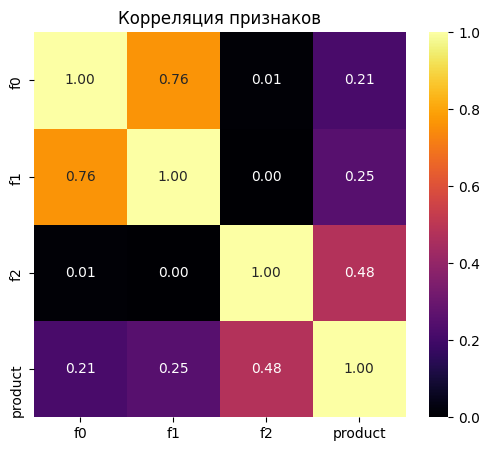

```python
# напишем функцию для построения phik_matrix()
# исключим id из анализа
# отобразим результат на тепловой картe
def phik_matrix(data):
    phik_data = data.drop(columns='id').phik_matrix()
    plt.figure(figsize=(6,5))
    plt.title(f'Корреляция признаков')
    sns.heatmap(phik_data, annot=True, fmt='.2f', cmap='inferno', vmin=0, vmax=1)
    return plt.show()

# вызовем функцию
phik_matrix(good_geo_data_0)
```

- Отсутствует мультиколлинеарность между признаками;
- С целевой переменной `product` коррелируют признаки: `f2`(**0.48**), `f1`(**0.25**), `f0`(**0.21**).

Построим матрицу корреляций для датафрейма `good_geo_data_1`:

```
interval columns not set, guessing: ['f0', 'f1', 'f2', 'product']
```

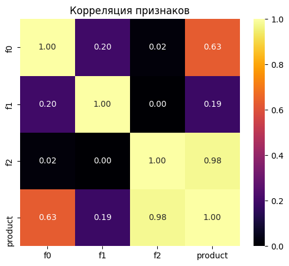

```python
# вызовем функцию для построения phik_matrix() и heatmap()
phik_matrix(good_geo_data_1)
```

- Между входными признаками отсутствует мультиколлинеарность;
- C целевым признаком коррелируют: `f2`(**0.98**), `f0`(**0.63**) и `f1`(**0.19**).

Рассчитаем корреляцию признаков в датафрейме `good_geo_data_2`:

```
interval columns not set, guessing: ['f0', 'f1', 'f2', 'product']
```

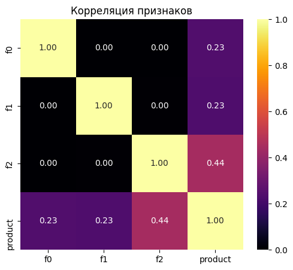

```python
# вызовем функцию
phik_matrix(good_geo_data_2)
```

- Тепловая карта показывает отсутствие мультиколлинеарности между признаками;
- С таргетом `product` коррелируют все признаки с характеристиками нефти: `f2`(**0.44**), `f1`(**0.23**), `f0`(**0.23**).

Проверим, есть ли линейная связь между входными и целевым признаками в датафрейме `good_geo_data_0`:

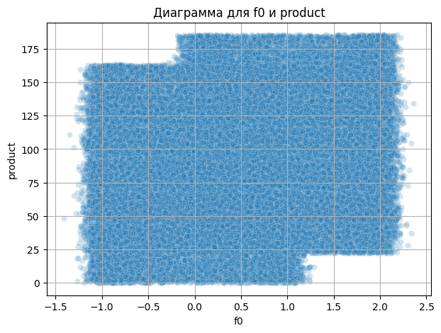

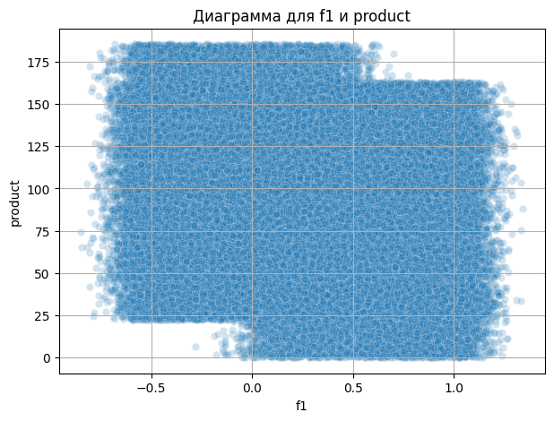

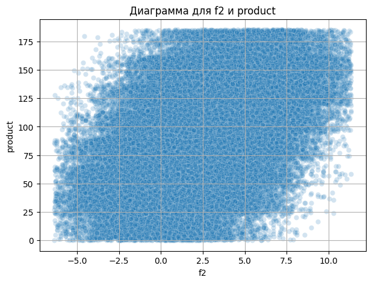

```python
# напишем функцию для построения диаграммы рассеяния
def scatterplot_creation(data):
    # получим список названий всех столбцов с помощью columns
    scatter_data = data.drop(columns=['id', 'product']).columns
    # будем перебирать все столбцы в датафрейме
    for column in scatter_data:
        plt.figure(figsize=(7,5))
        # берём таргет из исходного датафрейма
        sns.scatterplot(data=data, x=column, y='product', alpha=0.2)
        plt.title(f'Диаграмма для {column} и product')
        plt.grid(True)
        plt.show()

# вызовем функцию и построим диаграммы
scatterplot_creation(good_geo_data_0)
```

- Между входными признаками и таргетом отсутствует линейная связь.

Проверим, есть ли линейная связь между входными признаками и таргетом в датафрейме `good_geo_data_1`:

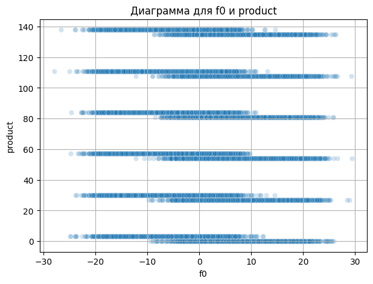

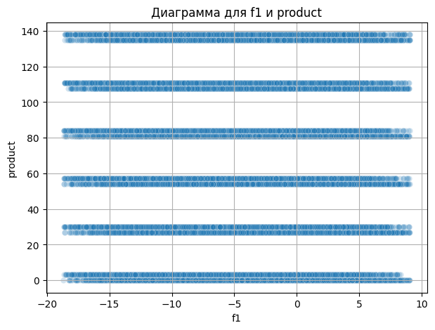

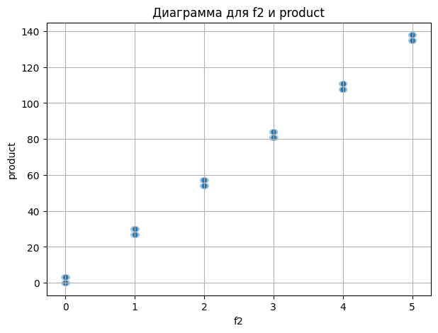

```python
# вызовем функцию и построим диаграммы
scatterplot_creation(good_geo_data_1)
```

- Можно заметить линейную связь между признаком `f2` и таргетом `product`.

Построим диаграмму рассеяния для каждого входного признака и таргета в датафрейме `good_geo_data_2`:

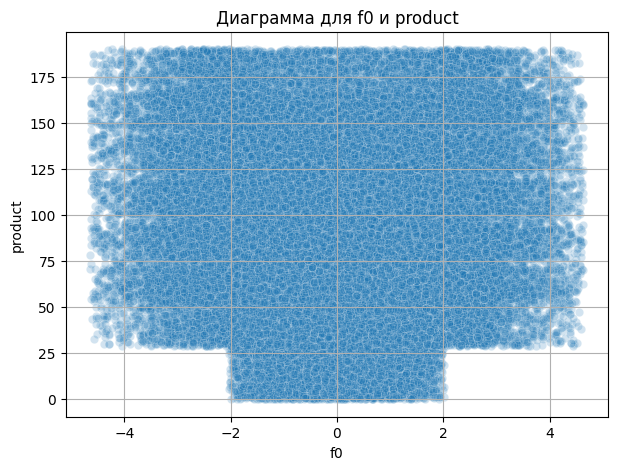

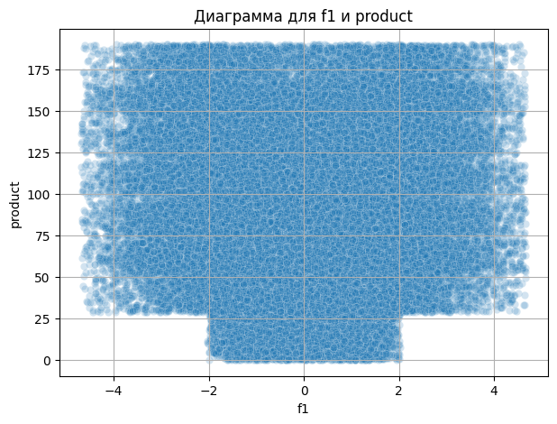

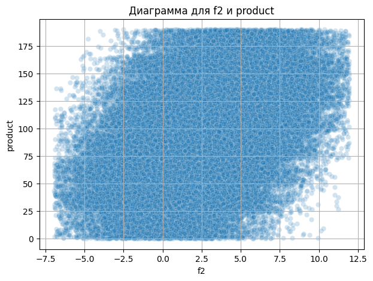

```python
# вызовем функцию и построим диаграммы
scatterplot_creation(good_geo_data_2)
```

- Диаграмма показывает отсутствие линейной связи между признаками.

**Выводы**:

В каждом датафрейме три входных признака коррелируют с таргетом `product` в разной степени:

- В `good_geo_data_0`: `f2`(**0.48**), `f1`(**0.25**), `f0`(**0.21**);
- В `good_geo_data_1`: `f2`(**0.98**), `f0`(**0.63**), `f1`(**0.19**);
- В `good_geo_data_2`: `f2`(**0.44**), `f1`(**0.23**), `f0`(**0.23**).

Мы обнаружили линейную связь между признаком `f2` и целевой переменной в датафрейме `good_geo_data_1`. Можно предположить, что во всех остальных случаях связь нелинейная.

Для устранения нелинейности переберём разные способы преобразования входных признаков в пайплайне:

- Логарифмирование;
- Квадратный корень;
- Возведение в степень.

## Обучение модели

### Создание пайплайна

Напишем пайплайн для обучения модели `линейной регрессии`:

```python
# обозначим количественные переменные для масштабирования
num_columns = [
    'f0',
    'f1',
    'f2'
]

# добавим логарифмирование
# используем log1p с защитой от отрицательных значений и NaN
# если число меньше -0.999, то заменяем его на -0.999
# затем берём логарифм от -0.999 + 1
# с помощью параметра validate=True проверим, что данные - двумерный массив
log_transformer = FunctionTransformer(lambda x: np.log1p(np.maximum(x, -0.999)), validate=True)

# возьмём квадратный корень из признаков
# прибавляем к числу 1
# если число меньше нуля - заменим его на ноль и возьмём корень из нуля
sqrt_transformer = FunctionTransformer(lambda x: np.sqrt(np.maximum(x + 1, 0)), validate=True)

# возведём признаки в квадрат
square_transformer = FunctionTransformer(lambda x: x ** 2, validate=True)

# заполним возможные пропуски средним, т.к. ранее почистили выбросы
imputer = SimpleImputer(strategy='mean')

# добавим разные скейлеры и способы для преобразования признаков
# учтём в переборе вариант без преобразований и масштабирования с помощью passthrough
preprocessors = [
    Pipeline([('imputer', imputer), ('passthrough', 'passthrough')]),
    Pipeline([('imputer', imputer), ('scaler', StandardScaler())]),
    Pipeline([('imputer', imputer), ('scaler', MinMaxScaler())]),
    Pipeline([('imputer', imputer), ('scaler', RobustScaler())]),
    Pipeline([('imputer', imputer), ('log', log_transformer)]),
    Pipeline([('imputer', imputer), ('sqrt', sqrt_transformer)]),
    Pipeline([('imputer', imputer), ('square', square_transformer)]),
]

# создадим итоговый пайплайн для обучения
pipe_final = Pipeline([
    ('preprocessor', 'passthrough'),
    ('model', LinearRegression())
])

# применим способы преобразования и масштабирования к столбцам в num_columns
# после трансформации с помощью remainder='drop' выкинем издатасета все колонки, которые не входят в num_columns
param_grid = {
    'preprocessor': [
        ColumnTransformer([('num', prep, num_columns)], remainder='drop')
        for prep in preprocessors
    ]
}

# переберём гиперпараметры по сетке GridSearchCV
# укажем 5 K-folds для кросс-валидации
# оценим качество с помощью RMSE
search = GridSearchCV(
    pipe_final,
    param_grid=param_grid,
    cv=5,
    scoring='neg_root_mean_squared_error',
    n_jobs=-1
)
```

### Обучение модели

#### Обучение и предсказание на данных good_geo_data_0

Обучим пайплайн на данных `good_geo_data_0`:

```python
# выделим входные и целевой признаки
# удалим признак 'id', который может создавать шум
X_train, X_test, y_train, y_test = train_test_split(
    good_geo_data_0.drop(columns=['product', 'id']),
    good_geo_data_0['product'],
    test_size=TEST_SIZE,
    random_state=RANDOM_STATE
)

# обучим пайплайн
search.fit(X_train, y_train)
```

```
GridSearchCV(cv=5,
             estimator=Pipeline(steps=[('preprocessor', 'passthrough'),
                                       ('model', LinearRegression())]),
             n_jobs=-1,
             param_grid={'preprocessor': [ColumnTransformer(transformers=[('num',
                                                                           Pipeline(steps=[('imputer',
                                                                                            SimpleImputer()),
                                                                                           ('passthrough',
                                                                                            'passthrough')]),
                                                                           ['f0',
                                                                            'f1',
                                                                            'f2'])]),
                                          ColumnTransformer(transformers=[('num',
                                                                           Pipeline(steps=[('imputer',
                                                                                            Simpl...
                                                                                            SimpleImputer()),
                                                                                           ('sqrt',
                                                                                            FunctionTransformer(func=<function <lambda> at 0x000001E7BFE25DC0>,
                                                                                                                validate=True))]),
                                                                           ['f0',
                                                                            'f1',
                                                                            'f2'])]),
                                          ColumnTransformer(transformers=[('num',
                                                                           Pipeline(steps=[('imputer',
                                                                                            SimpleImputer()),
                                                                                           ('square',
                                                                                            FunctionTransformer(func=<function <lambda> at 0x000001E7BFE25F70>,
                                                                                                                validate=True))]),
                                                                           ['f0',
                                                                            'f1',
                                                                            'f2'])])]},
             scoring='neg_root_mean_squared_error')
```

Выберем лучшую модель и посмотрим на её параметры:

```python
# выберем лучшую модель
best_model = search.best_estimator_

# выведем результат
f'Лучшая модель на валидации и её параметры:', best_model
```

```
('Лучшая модель на валидации и её параметры:',
 Pipeline(steps=[('preprocessor',
                  ColumnTransformer(transformers=[('num',
                                                   Pipeline(steps=[('imputer',
                                                                    SimpleImputer()),
                                                                   ('passthrough',
                                                                    'passthrough')]),
                                                   ['f0', 'f1', 'f2'])])),
                 ('model', LinearRegression())]))
```

Лучше всего справилась модель без преобразования входных признаков.

Посмотрим на метрику RMSE:

```python
# добавим знак минус, так как sklearn возвращает отрицательное значение
f'Метрика лучшей модели: {round(- search.best_score_, 2)}'
```

```
'Метрика лучшей модели: 37.7'
```

Согласно значению корня среднеквадратичной ошибки (RMSE), модель в среднем отклоняется от фактического значения на **37.7** тысяч баррелей.

Сделаем предсказания на валидационной выборке с помощью лучшей модели:

```python
# сделаем предсказание с помощью predict()
# сохраним предсказание в переменную y_pred
y_pred = best_model.predict(X_test)
```

Оценим качество модели с помощью корня среднеквадратичной ошибки, а также посчитаем средний запас реального и предсказанного сырья:

```python
# напишем функцию для расчетов
def rmse_mean_product(y_test, y_pred):
    # посчитаем метрику модели на валидации
    rmse = np.sqrt(mse(y_test, y_pred))
    # напечатаем результат
    return print(
    f'''
    Метрика модели RMSE на валидации: {round(rmse, 2)};
    Средний запас предсказанного сырья: {y_pred.mean()};
    Средний запас реального сырья: {y_test.mean()}'''
    )

# вызовем функцию
rmse_mean_product(y_test, y_pred)
```

```
    Метрика модели RMSE на валидации: 37.82;
    Средний запас предсказанного сырья: 92.35054696467081;
    Средний запас реального сырья: 92.31987881814342
```

На валидации метрика незначительно увеличилась на **0.12**.

**Выводы**:

Модель показала приемлемое качество:

- Лучше всего себя проявила модель без преобразования признаков;
- Метрика `RMSE` модели на валидационной выборке составляет — **37.82**. То есть, в среднем модель отклоняется от реального значения на **37.82** тысяч баррелей;
- Средние значения предсказанных и фактических запасов практически совпадают. Средний запас предсказанного сырья — около **92.35** тысяч баррелей, а реального — **92.31**.

#### Обучение и предсказание на данных good_geo_data_1

Обучим модель на данных датафрейма `good_geo_data_1`. Разделим данные, выделим целевой и входные признаки:

```python
# выделим входные и целевой признаки
# удалим признак 'id'
X_train_2, X_test_2, y_train_2, y_test_2 = train_test_split(
    good_geo_data_1.drop(columns=['product', 'id']),
    good_geo_data_1['product'],
    test_size=TEST_SIZE,
    random_state=RANDOM_STATE
)

# обучим пайплайн
search.fit(X_train_2, y_train_2)
```

```
GridSearchCV(cv=5,
             estimator=Pipeline(steps=[('preprocessor', 'passthrough'),
                                       ('model', LinearRegression())]),
             n_jobs=-1,
             param_grid={'preprocessor': [ColumnTransformer(transformers=[('num',
                                                                           Pipeline(steps=[('imputer',
                                                                                            SimpleImputer()),
                                                                                           ('passthrough',
                                                                                            'passthrough')]),
                                                                           ['f0',
                                                                            'f1',
                                                                            'f2'])]),
                                          ColumnTransformer(transformers=[('num',
                                                                           Pipeline(steps=[('imputer',
                                                                                            Simpl...
                                                                                            SimpleImputer()),
                                                                                           ('sqrt',
                                                                                            FunctionTransformer(func=<function <lambda> at 0x000001E7BFE25DC0>,
                                                                                                                validate=True))]),
                                                                           ['f0',
                                                                            'f1',
                                                                            'f2'])]),
                                          ColumnTransformer(transformers=[('num',
                                                                           Pipeline(steps=[('imputer',
                                                                                            SimpleImputer()),
                                                                                           ('square',
                                                                                            FunctionTransformer(func=<function <lambda> at 0x000001E7BFE25F70>,
                                                                                                                validate=True))]),
                                                                           ['f0',
                                                                            'f1',
                                                                            'f2'])])]},
             scoring='neg_root_mean_squared_error')
```

Выберем лучшую модель:

```python
# выберем лучшую модель
best_model_2 = search.best_estimator_

# напечатаем результат
f'Лучшая модель и её параметры:', best_model_2
```

```
('Лучшая модель и её параметры:',
 Pipeline(steps=[('preprocessor',
                  ColumnTransformer(transformers=[('num',
                                                   Pipeline(steps=[('imputer',
                                                                    SimpleImputer()),
                                                                   ('scaler',
                                                                    MinMaxScaler())]),
                                                   ['f0', 'f1', 'f2'])])),
                 ('model', LinearRegression())]))
```

Предскажем целевой признак `product` c помощью лучшей модели:

```python
# предскажем целевой признак на валидации и сохраним результат в переменную
y_pred_2 = best_model_2.predict(X_test_2)
```

Выведем метрику `RMSE` модели, средний предсказанный и фактический запасы:

```python
# выведем результат
rmse_mean_product(y_test_2, y_pred_2)
```

```
    Метрика модели RMSE на валидации: 0.89;
    Средний запас предсказанного сырья: 68.96189897916466;
    Средний запас реального сырья: 68.95632268086102
```

**Выводы**:

#### Обучение и предсказание на данных good_geo_data_2

Обучим модель на данных датафрейма `good_geo_data_2`:

```python
# разделим данные на выборки, выделим входной и целевой признаки
X_train_3, X_test_3, y_train_3, y_test_3 = train_test_split(
    good_geo_data_2.drop(columns=['product', 'id']),
    good_geo_data_2['product'],
    test_size=TEST_SIZE,
    random_state=RANDOM_STATE
)

# обучим пайплайн
search.fit(X_train_3, y_train_3)
```

```
GridSearchCV(cv=5,
             estimator=Pipeline(steps=[('preprocessor', 'passthrough'),
                                       ('model', LinearRegression())]),
             n_jobs=-1,
             param_grid={'preprocessor': [ColumnTransformer(transformers=[('num',
                                                                           Pipeline(steps=[('imputer',
                                                                                            SimpleImputer()),
                                                                                           ('passthrough',
                                                                                            'passthrough')]),
                                                                           ['f0',
                                                                            'f1',
                                                                            'f2'])]),
                                          ColumnTransformer(transformers=[('num',
                                                                           Pipeline(steps=[('imputer',
                                                                                            Simpl...
                                                                                            SimpleImputer()),
                                                                                           ('sqrt',
                                                                                            FunctionTransformer(func=<function <lambda> at 0x000001E7BFE25DC0>,
                                                                                                                validate=True))]),
                                                                           ['f0',
                                                                            'f1',
                                                                            'f2'])]),
                                          ColumnTransformer(transformers=[('num',
                                                                           Pipeline(steps=[('imputer',
                                                                                            SimpleImputer()),
                                                                                           ('square',
                                                                                            FunctionTransformer(func=<function <lambda> at 0x000001E7BFE25F70>,
                                                                                                                validate=True))]),
                                                                           ['f0',
                                                                            'f1',
                                                                            'f2'])])]},
             scoring='neg_root_mean_squared_error')
```

```python
# сохраним лучшую модель в переменную
best_model_3 = search.best_estimator_

# выведем параметры лучшей модели
f'Параметры лучшей модели:', best_model_3
```

```
('Параметры лучшей модели:',
 Pipeline(steps=[('preprocessor',
                  ColumnTransformer(transformers=[('num',
                                                   Pipeline(steps=[('imputer',
                                                                    SimpleImputer()),
                                                                   ('passthrough',
                                                                    'passthrough')]),
                                                   ['f0', 'f1', 'f2'])])),
                 ('model', LinearRegression())]))
```

Лучше всего справилась модель без преобразования признаков.

Предскажем целевой признак:

```python
# предскажем целевой признак и сохраним результат в переменную
y_pred_3 = best_model_3.predict(X_test_3)
```

Посчитаем `RMSE` и средние значения предсказанного и фактического запаса:

```python
# вызовем функцию для расчетов
rmse_mean_product(y_test_3, y_pred_3)
```

```
    Метрика модели RMSE на валидации: 40.13;
    Средний запас предсказанного сырья: 94.95178110761832;
    Средний запас реального сырья: 94.98612091398789
```

**Выводы**:

В целом, модель показала удовлетворительный результат:

- Лучший результат показала модель без преобразования признаков;
- В среднем, предсказание модели отклоняется от реальных данных на **40.13** тысяч баррелей. Значение в 2.3 раза меньше фактического объёма сырья;
- Средние значения предсказанного и реального объёма сырья практически совпадают: **94.95** и **94.98**.

## Расчёт прибыли

### Подготовка к расчёту прибыли

Сохраним в отдельных переменных все ключевые значения для расчётов:

```python
# бюджет на разработку скважин в регионе
budget_region = 10_000_000_000
# бюджет на одну скважину (выбирают 200 лучших скважин)
budget_per_well = budget_region / 200
# доход с одного барреля
one_barrel = 450
# доход с 1000 баррелей
thousand_barrels_income = one_barrel * 1000
```

Рассчитаем достаточный объём сырья для безубыточной разработки новой скважины:

```python
# разделим бюджет на одну скважину на доход с одной тысячи баррелей
# округлим результат до 3 знаков после запятой
f'Достаточный объём сырья для безубыточной разработки скважины: {round(budget_per_well / thousand_barrels_income, 3)} (тыс. баррелей)'
```

```
'Достаточный объём сырья для безубыточной разработки скважины: 111.111 (тыс. баррелей)'
```

Сравним полученный объём сырья со средним запасом в каждом регионе:

```python
# используем print для красивого вывода
print(f'''
    Средний запас в первом регионе good_geo_data_0: {round(y_test.mean(), 2)};
    Средний запас во втором регионе good_geo_data_1: {round(y_test_2.mean(), 2)};
    Средний запас в третьем регионе good_geo_data_2: {round(y_test_3.mean(), 2)}.''')
```

```
    Средний запас в первом регионе good_geo_data_0: 92.32;
    Средний запас во втором регионе good_geo_data_1: 68.96;
    Средний запас в третьем регионе good_geo_data_2: 94.99.
```

**Выводы**:

- В каждом регионе средний запас фактического сырья меньше достаточого объёма в **111** тысяч баррелей;
- Средний запас в третьем регионе (**94.99**) ближе всего к необходимому значению для безубыточной разработки скважины;
- Средний фактический запас во втором регионе (**68.9**) в 1.6 раз меньше, чем достаточный объём.

Чтобы принять финальное решение, проверим предсказания модели по 200 лучшим точкам для бурения скважин.

### Расчёт прибыли

Проверим, какую прибыль могут принести скважины с самым крупным объёмом сырья в соответствии с предсказаниями модели:

- Выберем индексы 200 скважин с самым большим объёмом предсказанного сырья;
- В соответствии с этими индесами отберём запасы 200 скважин в фактических данных;
- Рассчитаем суммарную прибыль от этих скважин в фактических данных.

Напишем функцию для расчёта прибыли по выбранным скважинам и предсказаниям модели:

```python
# напишем функцию
def income_count(y_pred, y_test):
    # выберем скважины с максимальными значениями предсказаний
    # оборачиваем предсказания в series c теми же индексами, что у фактических данных
    y_pred_series = pd.Series(y_pred, index=y_test.index)

    # получим индексы 200 предсказаний с макимальными значениями
    top_indicies = y_pred_series.sort_values(ascending=False).head(200).index

    # выберем соответствующие фактические объёмы по индексам в y_test
    top_targets = y_test.loc[top_indicies]

    # просуммируем целевое значение объёма сырья
    top_target_sum = top_targets.sum()

    # рассчитаем прибыль для полученного объёма сырья
    income_count = top_target_sum * 450_000 - budget_region

    # вернем прибыль
    return income_count
```

```python
# вызовем функцию для первого региона
income_count_1 = income_count(y_pred, y_test)

# выведем результат
f'Суммарная прибыль от 200 лучших скважин первого региона, отобранных по предсказаниям модели: {round(income_count_1)} рублей'
```

```
'Суммарная прибыль от 200 лучших скважин первого региона, отобранных по предсказаниям модели: 3252359903 рублей'
```

```python
# вызовем функцию для второго региона
income_count_2 = income_count(y_pred_2, y_test_2)

# выведем результат
f'Суммарная прибыль от 200 лучших скважин второго региона: {round(income_count_2)} рублей'
```

```
'Суммарная прибыль от 200 лучших скважин второго региона: 2415086697 рублей'
```

```python
# вызовем функцию для третьего региона
income_count_3 = income_count(y_pred_3, y_test_3)

# выведем результат
f'Суммарная прибыль от 200 лучших скважин третьего региона: {round(income_count_3)} рублей'
```

```
'Суммарная прибыль от 200 лучших скважин третьего региона: 2385314466 рублей'
```

**Выводы**:

- Самую большую прибыль может принести первый регион: **3 252 359 903** рублей;
- Суммарный доход от второго и третьего региона также превышает бюджет на разработку скважин — на **2 415 086 697** и **2 385 314 466** рублей.

### Подсчёт рисков и прибыли для регионов

С помощью техники `Bootstrap` подсчитаем риски и прибыль для каждого региона:

```python
# оборачиваем предсказания для регионов в Series с теми же индексами, что у фактических данных
y_pred_region_1 = pd.Series(y_pred, index=y_test.index)
y_pred_region_2 = pd.Series(y_pred_2, index=y_test_2.index)
y_pred_region_3 = pd.Series(y_pred_3, index=y_test_3.index)
```

```python
# напишем функцию с параметрами: предсказания, фактические значения, кол-во повторений эксперимента, размер выборки (кол-во скважин)
def bootstrap_profit_distribution(predictions, target, n_bootstrap=1000, sample_size=500):
    # фиксируем случайность
    state=np.random.RandomState(42)
    # создаём список для сбора прибыли в каждом эксперименте
    values=[]

    # цикл повторяется 1000 раз
    for _ in range(n_bootstrap):
        # берем случайные индексы из массива с предсказаниями
        # выбираем 500 скважин с возвращением (можем выбрать одну и ту же скважину несколько раз)
        indices = state.choice(len(predictions), size=sample_size, replace=True)
        # берём предсказания для выбранных случайных скважин
        sample_predictions = predictions[indices]
        # берём фактические значения для тех же скважин
        sample_target = target[indices]
        # считаем прибыль
        # сортируем индексы предсказаний по возрастанию с помощью argsort()
        # выберем топ-200 лучших по предсказаниям
        # выберем фактические запасы по индексам для 200 скважин
        # суммируем фактические запасы в 200 скважинах
        # умножим на доход с каждой единицы нефти, вычитаем инвестиции на разработку 200 скважин (10_000_000_000)
        profit = sample_target[sample_predictions.argsort()[-200:]].sum() * thousand_barrels_income - budget_region
        # сохраним доход в список
        values.append(profit)
    # вернём распределение прибыли по всем 1000 итерациям
    return values
```

Используем `Bootstrap` для каждого региона:

```python
# вызовем функцию
# выберем значения из Series c помощью values
# сохраним результат
profit_distribution_1 = bootstrap_profit_distribution(y_pred_region_1.values, y_test.values)
```

```python
# вызовем функцию для второго региона
profit_distribution_2 = bootstrap_profit_distribution(y_pred_region_2.values, y_test_2.values)
```

```python
# вызовем функцию для третьего региона
profit_distribution_3 = bootstrap_profit_distribution(y_pred_region_3.values, y_test_3.values)
```

Найдём среднюю прибыль для каждого региона:

```python
# преобразуем списки значений в numpy массивы для расчетов
profit_distribution_1 = np.array(profit_distribution_1)
profit_distribution_2 = np.array(profit_distribution_2)
profit_distribution_3 = np.array(profit_distribution_3)

# рассчитаем среднюю прибыль
profit_mean_1 = profit_distribution_1.mean()
profit_mean_2 = profit_distribution_2.mean()
profit_mean_3 = profit_distribution_3.mean()
```

Рассчитаем 95%-й доверительный интервал, в котором с 95%-й вероятностью находится настоящее среднее значение:

```python
# рассчитаем доверительный интервал для трёх регионов
confidence_interval_1 = np.percentile(profit_distribution_1, [2.5, 97.5])
confidence_interval_2 = np.percentile(profit_distribution_2, [2.5, 97.5])
confidence_interval_3 = np.percentile(profit_distribution_3, [2.5, 97.5])
```

Рассчитаем риск убытков:

```python
# рассчитаем риск убытков для каждого региона
# вернем массивы из True и False
# преобразуем True в 1, False в 0
# посчитаем среднее - долю убытков
risk_loss_1 = (profit_distribution_1 < 0).mean()
risk_loss_2 = (profit_distribution_2 < 0).mean()
risk_loss_3 = (profit_distribution_3 < 0).mean()
```

Визуализируем распределение и расчёты с помощью гистограммы:

```python
# напишем функцию для построения гистограммы
def hist_distribution(distribution, mean, interval, risk, title):
    plt.figure(figsize=(10,6))
    sns.histplot(distribution, bins=50, color='green')

    # добавим среднее, доверительный интервал и риск убытков
    plt.axvline(mean, color='orange', linestyle='dashed', label=f'Средняя прибыль: {mean:.2f}')
    plt.axvline(interval[0], color='red', linestyle='dashed', label=f'Левая граница интервала 95%: {interval[0]:.2f}')
    plt.axvline(interval[1], color='red', linestyle='dashed', label=f'Правая граница интервала 95%: {interval[1]:.2f}')

    # добавим подписи
    plt.title(title)
    plt.ylabel('Частота')
    plt.xlabel('Прибыль в рублях')
    plt.legend()
    plt.grid(True)

    # выведем риск
    plt.annotate(f'Риск убытков: {risk:.2%}', xy=(0.01,0.50), horizontalalignment='left', verticalalignment='top', xycoords='axes fraction')

    # автоматически расставим подписи
    plt.tight_layout()
    plt.show()
```

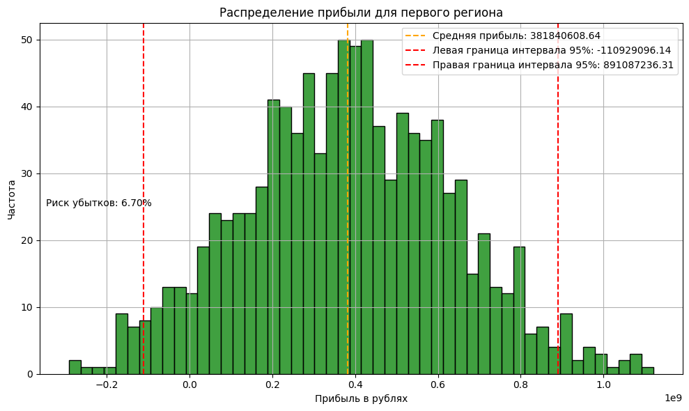

```python
# вызовем функцию для первого региона
hist_distribution(profit_distribution_1, profit_mean_1, confidence_interval_1, risk_loss_1, 'Распределение прибыли для первого региона')
```

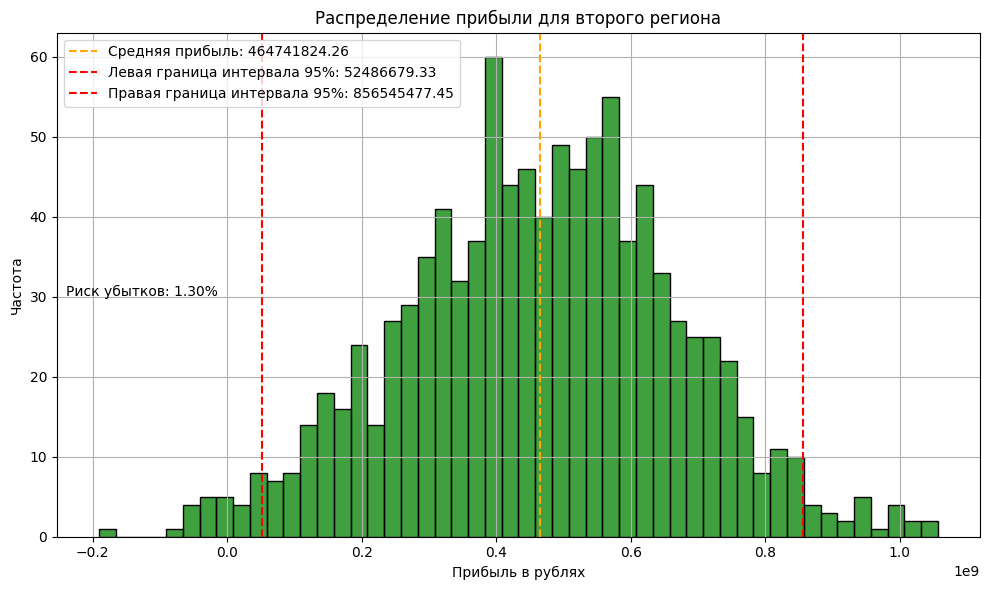

```python
# вызовем функцию для второго региона
hist_distribution(profit_distribution_2, profit_mean_2, confidence_interval_2, risk_loss_2, 'Распределение прибыли для второго региона')
```

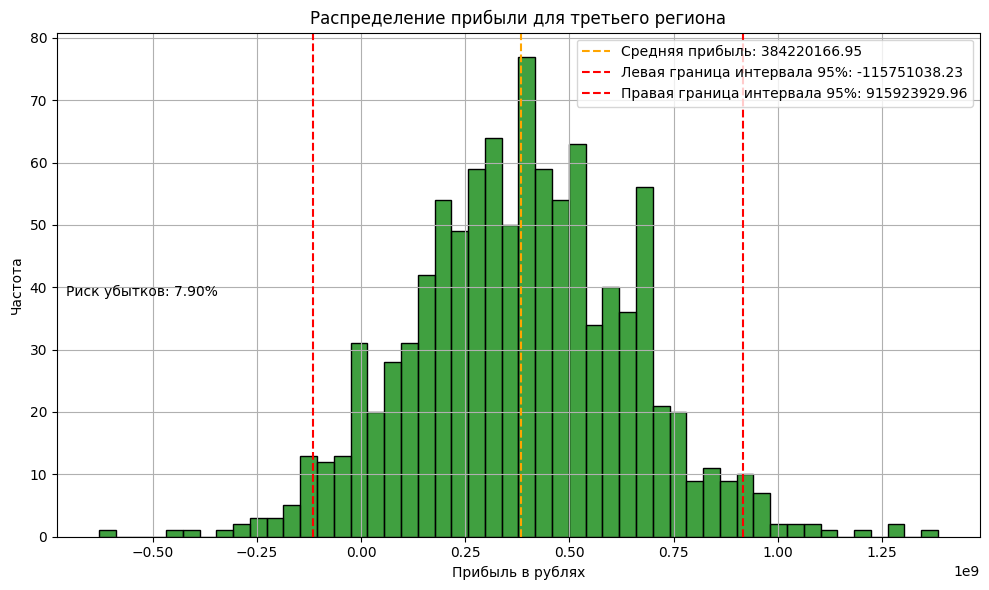

```python
# вызовем функцию для третьего региона
hist_distribution(profit_distribution_3, profit_mean_3, confidence_interval_3, risk_loss_3, 'Распределение прибыли для третьего региона')
```

**Выводы**:

- Лучше всего для разработки скважин подходит `второй регион`, так как он предполагает самый низкий риск убытков — **1.30** %, а также самую высокую среднюю прибыль — **464 741 824** рублей.

## Общий вывод

- В ходе предобработки данных проверили данные на наличие явных дубликатов.
- В ходе исследовательского анализа мы обнаружили и удалили выбросы во всех таблицах, обнаружили корреляцию трёх признаков (`f0`, `f1`, `f2`) с целевой переменной в каждом датафрейме, а также нелинейную и линейную (в `good_geo_data_1`: `f2` и `target`) связь между признаками.
- Для устранения нелинейности перебрали разные способы преобразования (логарифмирование, квадратный корень, возведение в степень) и масштабирования входных признаков в пайплайне.
- Мы обучили 3 модели. Лучше всего справилась модель, обученная на данных `второго региона`: `RMSE` составляет **890** баррелей, что меньше реального среднего почти в **76** раз.
- Второй регион подходит для разработки скважин лучше всего. Риск убытков составил **1.30** %, а средняя прибыль — **464 741 824** рублей.